# DESeq Analysis of U2AF1, U2AF2, SF1

- Show All Code
- Hide All Code
- View Source

Author

Kim Nguyen

Published

August 21, 2025

# 1 Introduction

## 1.1 Background information

This practical course (F2/ 3-month internship) is aimed to investigate the role of trans-acting RNA splicing factors in the regulation of alternative splicing, and how their dysfunction can contribute to cancer and tumor growth. The project begins by exploring the fundamental mechanisms of splicing, particularly the involvement of key trans-factors such as U2AF2, U2AF1, and SF1. These proteins play crucial roles in recognizing the 3′ splice site (AG), facilitating exon definition, and promoting lariat formation during intron removal, ultimately contributing to the production of mature mRNA.

## 1.2 Objectives / Research Questions

Learning objectives: - Idenitfy key significantly regulated genes and their expression patterns. - Analyze relationships between DEG statistics. - Understand functional gene associations using Gene Ontology terms (enrichGO and g:GOST) - Explore functional correlation among splice factors * Hypotheses: - Gene expression and Splicing interaction networks are changed upon knockdown of U2AF2, U2AF1, and SF1 leading to changes in their functional enrichment.

## 1.3 Significance of the Study

Alternative splicing plays a critical role in gene regulation and has been widely implicated in cancer development. This analysis is further researching how the splicing factors, particularly 3 genes of interest (U2AF1, U2AF2, and SF1), influences revealing insight into oncogenic process and potential therapeutic targets.

### 1.3.1 Data Sources

For this study, publicly raw RNA-seq datasets (fastq files) were obtained from the ENCODE project, which are silienced or reduced the expression using short hairpin RNA (shRNA) targeting U2AF2, U2AF1, and SF1 in the HepG2 liver cancer cell line (originating from a 15-year-old white male donor). Both shRNA-treated and control samples are replicated isogenic (that are genetically identical) which help reduce variability and makes it easier to attribute observed differences.

The data analysis pipeline includes several key steps: ### Data Preprocessing and tools (version number) - quality control using FastQC and MultiQC - adapter trimming with Trimmomatic - read alignment to the reference genome using STAR aligner - quantification of gene expression with HTSeq-count - visualization of mapped reads using IGV genome browser.

# 2 Input

- Library input

```r
# For Plotting & Visualization
library(ggplot2)
library(tidyverse)
library(plotly)
library(RColorBrewer)
library(ggrepel)
library(markdown)
library(ggrastr)
library(ggpointdensity)
library(magrittr)
library(dplyr)
library(gridExtra)
library(magrittr)
library(magick)
library(RColorBrewer)
library(colorRamp2)
library(ggvenn)
library(kableExtra)
library(shadowtext)
library(eulerr)
library(UpSetR)
library(ggshadow)
library(ggforce)
library(ggpp)
library(ggsankey)
library(networkD3)
library(ggalluvial)
library(ggforce)
library(tidyr)
library(corrplot)
library(Polychrome)

# For analysis
library(pheatmap)
library(ComplexHeatmap)
library(pcaExplorer) #interactive tool for exploring PCA
library(DESeq2)
library(gprofiler2)
library(clusterProfiler)
library(enrichplot)

# annotated human genome
library(org.Hs.eg.db)
library(AnnotationDbi)
library(Homo.sapiens)

#to combine multiple ggplot
library(patchwork)
library(reshape2)
library(ggpubr)

#outpath for all results of DESeq2 analysis
mydir = "/Users/tinkienoob/Master_thesis/HepG2_DESeq_analysis"
```

- Load result from another documents

```r
load("/Users/tinkienoob/Master_thesis/HepG2_DESeq_analysis/all_results_df_DESeq2.RData")
load("/Users/tinkienoob/Master_thesis/HepG2_DESeq_analysis/gene_anno.RData")

# Create a list of dds result of each pair of KD and control
res_list = list(U2AF1 = res_U2AF1.df, U2AF2 = res_U2AF2.df, SF1 = res_SF1.df)
```

- Load significant junction changing results

```r
outpath = "/Users/tinkienoob/Master_thesis/Functional splice factor analysis/"
U2AF2_highest_junction = readRDS(paste0(outpath, "U2AF2_highest_junction.rds"))
U2AF1_highest_junction = readRDS(paste0(outpath, "U2AF1_highest_junction.rds"))
SF1_highest_junction = readRDS(paste0(outpath, "SF1_highest_junction.rds"))
```

## 2.1 Splicing annotation - Core spliceosome components input

Input annotation file collected from paper: https://www.science.org/doi/10.1126/science.adn8105 (Malgorzata E. Rogalska et al. ,Transcriptome-wide splicing network reveals specialized regulatory functions of the core spliceosome.Science386,551-560(2024).DOI:10.1126/science.adn8105) which contain gene names and geneID of core spliceosome components (from both major and minor spliceosomes) and associated factors, RNA binding proteins with known regulatory functions in AS, , and RNA-modifying enzymes and chromatin-related factors linked to splicing regulation.

### 2.1.1 Correlation-based network of SFs

Cross-regulatory networks of splicing genes involve intricate feedback loops where splicing factors (proteins that regulate splicing) influence the splicing of other splicing factors, creating a complex web of interactions. These networks are crucial for controlling gene expression and cellular processes. They differ from transcriptional regulatory networks in their hierarchical organization, with fewer master regulators and more interconnected regulatory relationships among splicing factors. This can happen through direct binding of a splicing factor to a splicing regulatory element (SRE) on another splicing factor’s pre-mRNA.

For these splice factors, identify, a. Their Correlation value with the splice factor pair by referring to the supplement table 9. For example, if the splice factor in red is your favorite, then the tg column indicates the SF pair it might be linked to, and the cor column indicates their correlation based on the similarities in AS changes following their perturbation.

the columns so and tg likely stand for: so = Source gene in the edge tg = Target gene in the edge cor = Correlation coefficient (likely Pearson or Spearman) absCor = Absolute value of correlation fdr = False discovery rate (adjusted p-value) for correlation

```r
correlation_anno_xlsx = "/Users/tinkienoob/Master_thesis/HepG2_DESeq_analysis/AS_regulatory network.xlsx"
correlation_anno = read_excel(correlation_anno_xlsx)

correlation_anno = correlation_anno %>%
  dplyr::select(edges, so, tg, cor)

correlation_anno = correlation_anno %>%
  left_join(as_anno, by = c("so" = "splice_SYMBOL")) %>%
  rename(source_class = class) %>%
  dplyr::select(-c("splice_ENSEMBL"))

correlation_anno = correlation_anno %>%
  left_join(as_anno, by = c("tg" = "splice_SYMBOL")) %>%
  rename(target_class = class) %>%
  dplyr::select(-c("splice_ENSEMBL"))

#view(correlation_anno)
```

# 3 Differential Expression / Functional and Splicing Analysis using R studio

The primary goal is to identify genes/transcripts whose expression levels significantly differ between knockdown and control conditions. The changes in regulation interpret the biological impact of interested splicing factor depletion. https://bioconductor.org/packages/devel/bioc/manuals/DESeq2/man/DESeq2.pdf

## 3.1 Volcano plot of each KD dataset

Volcano plot is used to evaluate differential expression of genes in statistics way, Log2FoldChange cutoff is set to larger than 1 which is actual fold change equal to 2 and threshold for padj is < 0.05 that filter only significantly differential expressed genes. - LFC > 1: This means the gene’s expression is 2 times higher in the test condition compared to the control. By that, most upregulated or downregulated genes are shown on Volcano plot and enriched by GO enirchment to investigate biological processes those genes involved in. Each KDs might cause indirect or direct effects on different biological processes.

Volcano plot also uses a corrected version of padj (adjusted p-value) is to handle extreme values of -log10(padj) that would otherwise distort the plot. In other words, significant adjusted p-values are usually extremely small, therefore, -log10(padj) is used to transform the padj into the larger positive values which is easier to visualize. The smaller padj values, the higher -log10(padj) value, the more significant.

The question have been raising is that Differential expression of those genes is directly or indirectly affected by KD genes? Direct effects is when loss or change in function of SF might change pre-mRNA leading to formation of different isoform proteins (AUTOREGULATION) or instability of mRNA then nonsense mediated decay (NMD) via inclusion of premature termination codons. Whereas, in indirect effects, other SF genes in complex splicing network (secondary SFs) might involve that change gene expression or downstream regulation via alternative splicing (CROSS-regulation).

Rogalska, M. E., Mancini, E., Bonnal, S., Gohr, A., Dunyak, B. M., Arecco, N., … & Valcárcel, J. (2024). Transcriptome-wide splicing network reveals specialized regulatory functions of the core spliceosome. Science, 386(6721), 551-560.

**U2AF1 dataset**

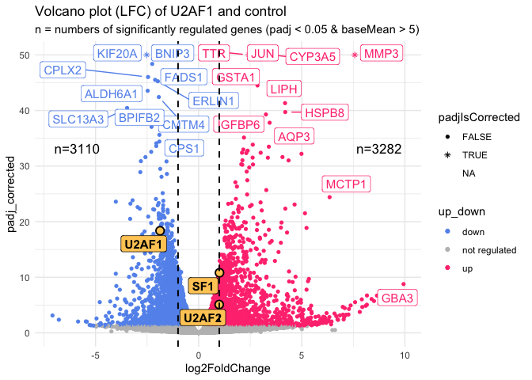

```r
#-log10(120) = -2.079181
# convert small padj into larger -log10(padj) value and padjIsCorrected ~ 50 is used to scale up the value for better visualization
volcano_U2AF1.df = dplyr::mutate(res_U2AF1.df,
                      padjIsCorrected = -log10(padj) > 50, # If -log10(padj) is greater than 50, mark it as TRUE.
                      padj_corrected = case_when(
                        padjIsCorrected ~ 50,
                        TRUE ~ -log10(padj)
                      ))

# Volcano plot of U2AF1
ggplot(volcano_U2AF1.df, aes(x= log2FoldChange, y= padj_corrected, shape= padjIsCorrected, color= up_down, label= SYMBOL)) +
  geom_point() +
  geom_point(data = subset(volcano_U2AF1.df, !is.na(myLabel)),
             fill = "#FFCC65FF", color = "black", size = 3, shape = 21, stroke = 1) +
  geom_label_repel(data = subset(volcano_U2AF1.df, !is.na(myLabel)),
                   aes(x = log2FoldChange,
                       y = padj_corrected,
                       label = SYMBOL,
                       fontface = "bold"),
                   color = "black",
                   fill = "#FFCC65FF",
                   size = 4,
                   show.legend = FALSE) +
  scale_color_manual(values= c("up" = "#FF3D7FFF", "down" = "cornflowerblue", "not regulated" = "grey")) +
  geom_label_repel(data = subset(volcano_U2AF1.df, abs(log2FoldChange) > 1 & baseMean > 5), # Label genes with significant LFC (up regulation and downregulation)
                   aes(x = log2FoldChange,
                       y = padj_corrected,
                       label = SYMBOL),
                   point.padding = 0.7,
                   max.overlaps = 10,
                   size = 4,
                   show.legend = FALSE) +
  theme_minimal() +
  labs(title = "Volcano plot (LFC) of U2AF1 and control",
       subtitle = "n = numbers of significantly regulated genes (padj < 0.05 & baseMean > 5)") +
  scale_shape_manual(values = c("TRUE" = 8, "FALSE" = 16)) +
  geom_vline(xintercept = c(1, -1), linetype= "dashed", color = "black", size = 0.7) +
  stat_quadrant_counts(data = subset(volcano_U2AF1.df, padj < 0.05 & baseMean > 5),
                       aes(label = after_stat(count.label)), size = 4.5, vjust = 10)
```

compensatory transcriptional ↑ U2AF2 and SF1 to maintain other splicing interaction efficiency

**U2AF2 dataset**

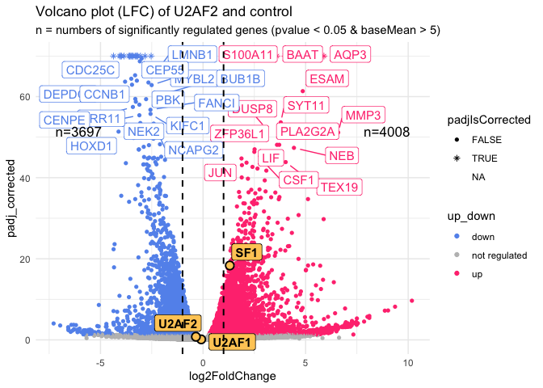

```r
# Compute -log10(padj)
volcano_U2AF2.df = dplyr::mutate(res_U2AF2.df,
                                 padjIsCorrected = -log10(padj) > 70,
                                 padj_corrected = case_when(
                                   padjIsCorrected ~ 70,
                                   TRUE ~ -log10(padj)
                                 ))
# Volcano plot
ggplot(volcano_U2AF2.df, aes(x= log2FoldChange, y= padj_corrected, shape= padjIsCorrected, color= up_down, label = SYMBOL)) +
  geom_point() +
  geom_point(data = subset(volcano_U2AF2.df, !is.na(myLabel)),
             fill = "#FFCC65FF", color = "black", size = 3, shape = 21, stroke = 1) +
  geom_label_repel(data = subset(volcano_U2AF2.df, !is.na(myLabel)), # label my label
                   aes(x = log2FoldChange,
                       y = padj_corrected,
                       label = SYMBOL,
                       fontface = "bold"),
                   color = "black",
                   fill = "#FFCC65FF",
                   point.padding = 0.5,
                   max.overlaps = 10,
                   size = 4,
                   show.legend = FALSE) +
  scale_color_manual(values= c("up" = "#FF3D7FFF", "down" = "cornflowerblue", "not regulated" = "grey")) +
  geom_label_repel(data = subset(volcano_U2AF2.df, abs(log2FoldChange) > 1 & baseMean > 5), # Label genes with significant regulated genes
                   aes(x = log2FoldChange,
                       y = padj_corrected,
                       label = SYMBOL),
                   point.padding = 0.7,
                   max.overlaps = 22,
                   size = 4,
                   show.legend = FALSE) +
  theme_minimal() +
  labs(title = "Volcano plot (LFC) of U2AF2 and control",
       subtitle = "n = numbers of significantly regulated genes (pvalue < 0.05 & baseMean > 5)") +
  scale_shape_manual(values = c("TRUE" = 8, "FALSE" = 16)) +
  geom_vline(xintercept = c(1, -1), linetype= "dashed", color = "black", size = 0.7) +
  stat_quadrant_counts(data = subset(volcano_U2AF2.df, padj < 0.05 & baseMean > 5),
                       aes(label = after_stat(count.label)),
                       size = 4.5, vjust = 8)
```

↑ SF1 preserves early recognition of BP and interacts with U2AF2 for recruiting the U2 snRNP

**SF1 dataset**

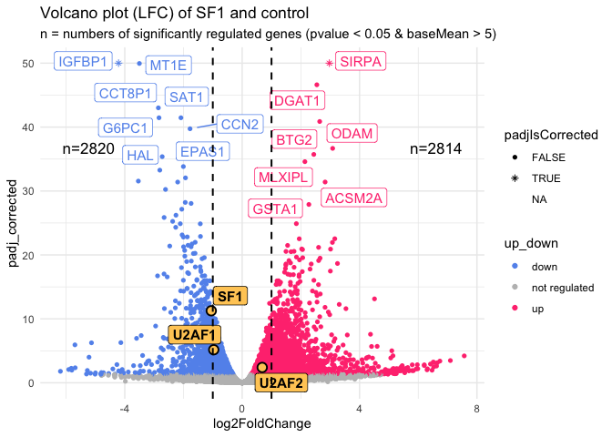

```r
# Compute -log10(adj)
volcano_SF1.df = dplyr::mutate(res_SF1.df,
                                 padjIsCorrected = -log10(padj) > 50,
                                 padj_corrected = case_when(
                                   padjIsCorrected ~ 50,
                                   TRUE ~ -log10(padj)
                                 ))

# Extract quadrant counts manually:
SF1_sigreg_quad = volcano_SF1.df %>%
  filter(abs(log2FoldChange) > 1 & padj < 0.05) %>%
  dplyr::select(c(GeneID, up_down))

# Volcano plot
ggplot(volcano_SF1.df, aes(x= log2FoldChange, y= padj_corrected,
                           shape= padjIsCorrected, color= up_down, label = SYMBOL)) +
  geom_point() +
  geom_point(data = subset(volcano_SF1.df, !is.na(myLabel)), # Label gene depletion
             fill = "#FFCC65FF", color = "black", size = 3, shape = 21, stroke = 1) +
  geom_label_repel(data = subset(volcano_SF1.df, !is.na(myLabel)),
                   aes(x = log2FoldChange,
                       y = padj_corrected,
                       label = SYMBOL,
                       fontface = "bold"),
                   color = "black",
                   fill = "#FFCC65FF",
                   point.padding = 0.5,
                   max.overlaps = 10,
                   size = 4,
                   show.legend = FALSE) +
  scale_color_manual(values= c("up" = "#FF3D7FFF", "down" = "cornflowerblue", "not regulated" = "grey")) +
  geom_label_repel(data = subset(volcano_SF1.df, abs(log2FoldChange) > 1 & baseMean > 5), # Label genes with significant regulated genes
                   aes(x = log2FoldChange,
                       y = padj_corrected,
                       label = SYMBOL),
                   point.padding = 0.7,
                   max.overlaps = 10,
                   size = 4,
                   show.legend = FALSE) +
  theme_minimal() +
  labs(title = "Volcano plot (LFC) of SF1 and control",
       subtitle = "n = numbers of significantly regulated genes (pvalue < 0.05 & baseMean > 5)") +
  scale_shape_manual(values = c("TRUE" = 8, "FALSE" = 16)) +
  geom_vline(xintercept = c(1, -1), linetype= "dashed", color = "black", size = 0.7) +
  stat_quadrant_counts(data = subset(volcano_SF1.df, padj < 0.05 & baseMean > 5),
                       aes(label = after_stat(count.label)),
                       size = 4.5, vjust = 8)
```

U2AF2 mild ↑ ➔ possibly to counteract early spliceosome defects from SF1 loss Question: Why U2AF1 loss cause downregulation in U2AF1?

## 3.2 Alluvial diagram of gene regulation across 3 knockdowns

```r
# use imap() to get both data and name of df in the list
res_list_bM5 = purrr::imap(res_list, function(x,cond) {
  x %>%
    filter(baseMean > 5) %>%
    dplyr::select(c("GeneID", "up_down")) %>%
    dplyr::rename(!!cond := up_down)}) # gives a column named of condition instead of "up_down"

# create df for alluvial diagram
# Join all 3 by GeneID
alluvial_df = purrr::reduce(res_list_bM5, left_join, by = "GeneID")

# check whether there is any NA value in df
#alluvial_df[is.na(alluvial_df)]

# Convert into alluvial format
alluvial_df2 = alluvial_df %>%
  group_by(U2AF2, U2AF1, SF1) %>%
  summarise(n = n(), .groups = "drop") %>%
  mutate(U2AF2 = factor(U2AF2, levels = c("up","not regulated", "down")))

alluvial_df2
```

```
# A tibble: 27 × 4
   U2AF2         U2AF1         SF1               n
   <fct>         <chr>         <chr>         <int>
 1 down          down          down            473
 2 down          down          not regulated   940
 3 down          down          up              185
 4 down          not regulated down            803
 5 down          not regulated not regulated  1086
 6 down          not regulated up               43
 7 down          up            down            111
 8 down          up            not regulated    51
 9 down          up            up                5
10 not regulated down          down             91
# ℹ 17 more rows
```

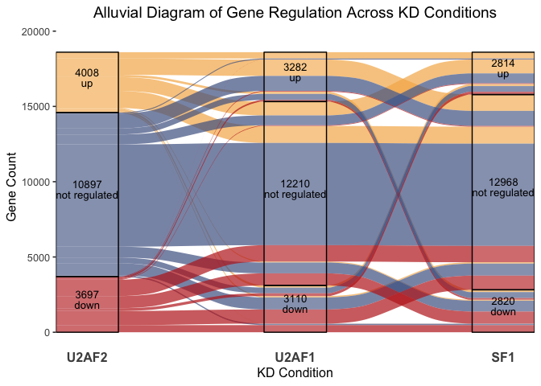

```r
ggplot(alluvial_df2,
       aes(axis1 = U2AF2,
            axis2 = U2AF1,
            axis3 = SF1,
            y = n)) +
  # Flow with unique color for each combination
  geom_alluvium(aes(fill = U2AF2), width = 1/3, alpha = 0.7) +

  # Strata color by first variable
  geom_stratum(color = "black", width = 0.3, alpha = .1) +

  # Text for strata
  geom_text(stat = "stratum",
            aes(label = after_stat(stratum)),
            size = 3.5) +

  # Text for total numbers of genes in each stratum
  geom_text(stat = "stratum",
            aes(label = after_stat(count)),
            nudge_y = 700,
            size = 3.5,
            check_overlap = TRUE) +

  scale_x_discrete(limits = c("U2AF2", "U2AF1", "SF1"), expand = c(0.05, 0.05)) +

  # Manual fill colors for up/down/not regulated
  scale_fill_manual(values = c(
    "up" = "#F5B355",
    "down" = "#BD241EFF",
    "not regulated" = "#4D6291")) +

  labs(y = "Gene Count", x = "KD Condition",
       title = "Alluvial Diagram of Gene Regulation Across KD Conditions") +

  theme_alluvial(base_size = 12) +
  theme(legend.position = "none",
        plot.title = element_text(hjust = 0.5),
        axis.text.x = element_text(face = "bold", size = 12))
```

### 3.2.1 Upregulated genes in all 3 datasets

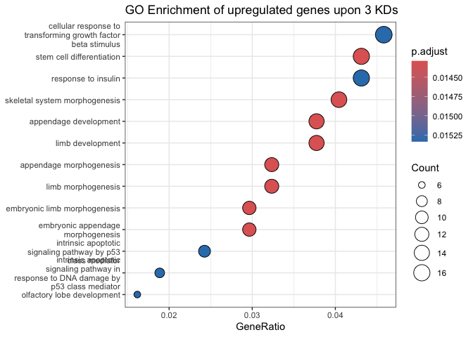

```r
# Extract genes upregulated in all 3 datasets
up_genes_all <- alluvial_df %>%
  filter(if_all(-GeneID, ~ . == "up")) %>%
  pull(GeneID)

ego_up_genes_all = enrichGO(gene = up_genes_all,
                OrgDb = org.Hs.eg.db,
                keyType = "ENSEMBL",
                ont = "BP",
                pAdjustMethod = "BH",
                readable = TRUE)

#as.data.frame(ego_wp2_sigreg_U2AF2_genes)

dotplot(ego_up_genes_all, showCategory = 13, font.size = 6,
        title = "GO Enrichment of upregulated genes upon 3 KDs") +
  theme_bw()
```

```r
# https://biit.cs.ut.ee/gplink/l/agc7Vfi3RRt
gpro_up_genes_all = gost(query = up_genes_all, # input geneIDs
                organism = "hsapiens", # organism of interest
                significant = TRUE, # return only the significant result
                exclude_iea = FALSE,  # do not exclude GO electronic annotation
                evcodes = TRUE, # include evidence code
                user_threshold = 0.05, # P-value threshold (eg. P value<= 0.05)
                correction_method = "g_SCS",  # Multiple testing correction method
                domain_scope = "annotated")
#                as_short_link = TRUE) # domain scope

# Filter for the term of interest
gene_expression_upall_df <- gpro_up_genes_all$result[grepl("gene expression|splicing|transcription", gpro_up_genes_all$result$term_name, ignore.case = TRUE), ]

# Extract the genes contributing to this GO term
gene_expression_upall = unique(unlist(strsplit(gene_expression_upall_df$intersection, split = ",")))
```

### 3.2.2 Downregulated genes in all 3 datasets

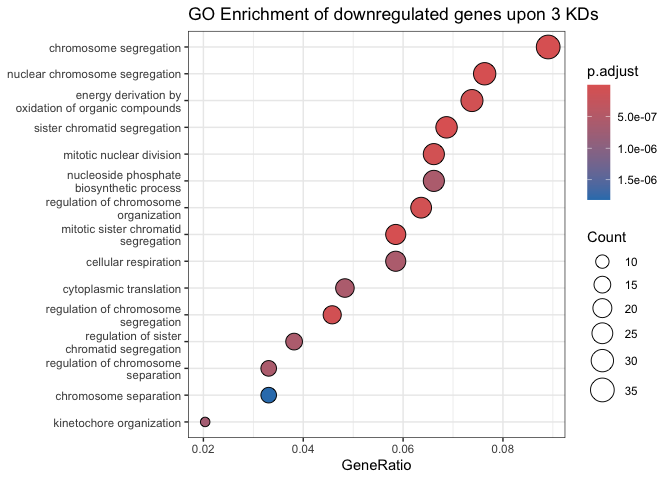

```r
# Extract genes downregulated in all 3 datasets
down_genes_all <- alluvial_df %>%
  filter(if_all(-GeneID, ~ . == "down")) %>%
  pull(GeneID)

ego_down_genes_all = enrichGO(gene = down_genes_all,
                OrgDb = org.Hs.eg.db,
                keyType = "ENSEMBL",
                ont = "BP",
                pAdjustMethod = "BH",
                readable = TRUE)

#as.data.frame(ego_wp2_sigreg_U2AF2_genes)

dotplot(ego_down_genes_all, showCategory = 15, font.size = 7,
        title = "GO Enrichment of downregulated genes upon 3 KDs") +
  theme_bw()
```

```r
# https://biit.cs.ut.ee/gplink/l/alRmZjbYHRu
gpro_down_genes_all = gost(query = down_genes_all, # input geneIDs
                organism = "hsapiens", # organism of interest
                significant = TRUE, # return only the significant result
                exclude_iea = FALSE,  # do not exclude GO electronic annotation
                evcodes = TRUE, # include evidence code
                user_threshold = 0.05, # P-value threshold (eg. P value<= 0.05)
                correction_method = "g_SCS",  # Multiple testing correction method
                domain_scope = "annotated",
                as_short_link = TRUE) # domain scope
```

## 3.3 Heatmap

This heatmap shows gene expression patterns across all samples (with rows representing genes and columns representing samples) to visualize co-regulated genes or differential expressed genes. Z-score is values representing how far a data point is from the mean, in units of standard deviation (sds - variation in gene expression). The result later can be used for clustering relative expression genes.

### 3.3.1 Normalization:

The count data of a particular generepresenting the number of sequence reads that reflects both gene expression and various technical factors. The higher the number of counts, the more reads associated with that gene, and the assumption that there was a higher level of expression of that gene in the sample. The counts of mapped reads for each gene is proportional to the expression of RNA (“interesting”) in addition to many other factors (“uninteresting”). Normalization is the process of scaling raw count values to account for the “uninteresting” factors. Normalization is essential to correct for these biases (e.g., sequencing depth, gene length, RNA composition), ensuring the expression levels are more comparable between and within samples and accurately reflect biological differences.

Key factors addressed during normalization: - Sequencing depth: Adjusts for varying numbers of reads per sample. - Gene length: Important for transcript-level quantification. - RNA composition: Accounts for highly expressed genes skewing the distribution. https://hbctraining.github.io/Training-modules/planning_successful_rnaseq/lessons/sample_level_QC.html

```r
dds = readRDS(paste0(mydir, "dds_DESeq2.dds"))

#Get normalized read counts of dds result
dds_count = DESeq2::counts(dds, normalized = TRUE)

#dds_count_df = as.data.frame(dds_count)

#rename rownames by remove the version of genes
rownames(dds_count) = sub("\\..*", "", rownames(dds_count))

# Convert into matrix
dds_matrix = as.matrix(dds_count)

# z-score normalization
# s1: remove rows without read counts
matrix_nozero = dds_matrix[apply(dds_matrix, MARGIN = 1, function(x)any(x!=0)), ] # MARGIN = 1 → operate across rows
                                                                                  # MARGIN = 2 → operate across columns

#calculate z-score (pairwise distances)
# s2: calculate rowmean
rowmeans = rowMeans(matrix_nozero, na.rm = TRUE)

# s3: calculate row-wise standard deviation
sds = apply(matrix_nozero, MARGIN = 1, function(x) sd(x, na.rm = TRUE))

matrix_nozero = matrix_nozero - rowmeans # gene expression value - row mean

# s4: Z-score normalization
matrix_nozero = matrix_nozero/sds

# Replace NA value with 0
matrix_nozero[is.na(matrix_nozero)] = 0
```

Now we have a matrix (matrix_nozero) containing z-scores. Z-score normalization per gene (row), which standardizes the expression across samples (each row will have a mean ~0 and std ~1 (except for rows with constant values)). Z-score is a form of standardization, but not a normalization method for RNA-seq counts. What you did: For each gene, you subtract the mean and divide by the standard deviation across samples. This gives relative up/down patterns per gene (red = higher than average, blue = lower). Purpose: visualize patterns/clustering, not absolute expression levels.

### 3.3.2 K-means clustering calculation

The first step when using k-means clustering is to indicate the number of clusters (k) that will be generated in the final solution. The algorithm starts by randomly selecting k objects from the data set to serve as the initial centers for the clusters. The selected objects are also known as cluster means or centroids. Next, each of the remaining objects is assigned to it’s closest centroid, where closest is defined using the Euclidean distance (Eq. 1) between the object and the cluster mean. This step is called “cluster assignment step”. After the assignment step, the algorithm computes the new mean value of each cluster. The term cluster “centroid update” is used to design this step. Now that the centers have been recalculated, every observation is checked again to see if it might be closer to a different cluster. All the objects are reassigned again using the updated cluster means. The cluster assignment and centroid update steps are iteratively repeated until the cluster assignments stop changing (i.e until convergence is achieved). That is, the clusters formed in the current iteration are the same as those obtained in the previous iteration.(with nstart is a number of random initial configurations (random sets of cluster centroids) the algorithm will try.) https://uc-r.github.io/kmeans_clustering ### Column cluster by genes

```r
set.seed(123)

columncluster = kmeans(t(matrix_nozero), centers = 5, nstart = 25) # t stands for transpose

# Extract and sort column cluster order
columnclusterorder = columncluster$cluster

columnclustersort = order(columnclusterorder)

# Correct diverging color palette (from blue to white to red)
#coLor = colorRamp2(c(-1, 0, 1), c("#0E54B6FF", "white", "#BD241EFF"))

coLor = colorRamp2(c(-1, 0, 1), c("#0E54B6FF", "white", "#BD241EFF"))
```

### 3.3.3 Heatmap with different kmeans to identify best clustering

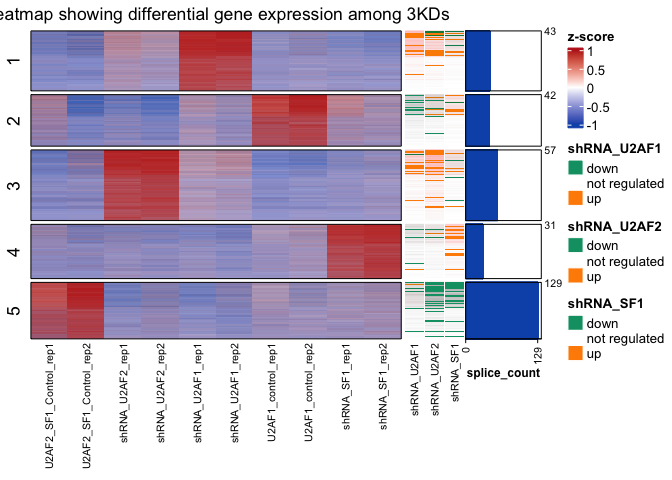

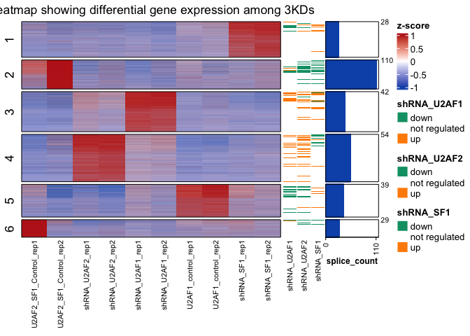

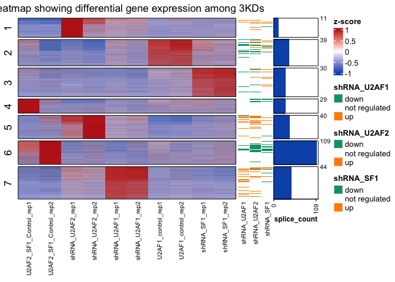

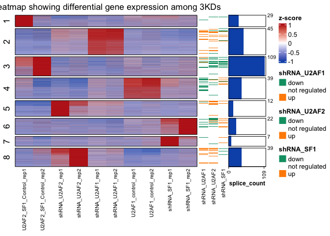

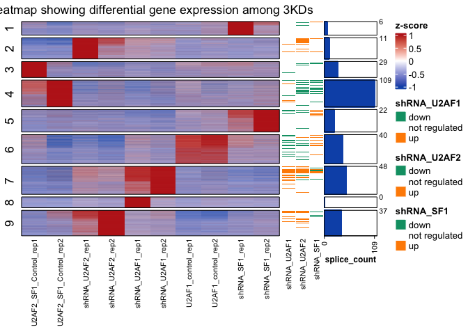

```r
# create a cluster list for later extract
cluster_list = list()

for (k in 5:9) {
  # cluster rows
  set.seed(123)

  ######################### 1. K-MEANS CLUSTERING
  rowclustermatrix = kmeans(matrix_nozero, centers = k, nstart = 25)

  # assign result of kmeans to cluster list kk
  cluster_list[[paste0("k", k)]] = rowclustermatrix

  # extract the clusters
  rowclusterorder = rowclustermatrix$cluster # use $ to isolate cluster in rowclustermatrix

  # sort the rows according to the cluster
  rowclustersort = order(rowclusterorder)

  # Rearrange normalized matrix according to clustering results so similar genes/samples appear together in the heatmap.
  dds_mat = matrix_nozero[rowclustersort, columnclustersort]

  ######################### 2. Regulation annotations for each knockdown condition
  # Annotate each rows (genes) on heatmap to see whether it's upregulated, downregulated, or not regulated across different samples.
  # U2AF1
  U2AF1_anno = rowAnnotation(shRNA_U2AF1 = res_U2AF1.df$up_down[match(rownames(dds_mat),res_U2AF1.df$GeneID)],
                           col = list(shRNA_U2AF1 = c("up" = "darkorange", "down" = "#009E73", "not regulated" = NA)),
                           annotation_name_gp = gpar(fontsize = 8))
  # U2AF2
  U2AF2_anno = rowAnnotation(shRNA_U2AF2 = res_U2AF2.df$up_down[match(rownames(dds_mat),res_U2AF2.df$GeneID)],
                           col = list(shRNA_U2AF2 = c("up" = "darkorange", "down" = "#009E73", "not regulated" = NA)),
                           annotation_name_gp = gpar(fontsize = 8))
  # SF1
  SF1_anno = rowAnnotation(shRNA_SF1 = res_SF1.df$up_down[match(rownames(dds_mat),res_SF1.df$GeneID)],
                           col = list(shRNA_SF1 = c("up" = "darkorange", "down" = "#009E73", "not regulated" = NA)),
                           annotation_name_gp = gpar(fontsize = 8))

  ########################## 3. Create bar box annotation for each row cluster
  # Extract the cluster assignments from the kmeans result
  row_split = rowclustermatrix$cluster  # numeric vector: cluster for each gene

  # Sort to match heatmap row order
  row_split = row_split[rowclustersort]

  # Ensure names match your heatmap matrix
  names(row_split) = rownames(dds_mat)

  # Identify splicing-related genes (TRUE/FALSE for each gene)
  splicing_genes_barplot <- rownames(dds_mat) %in% as_anno$splice_ENSEMBL

  # Get unique clusters (in sorted order)
  cluster_levels = sort(unique(row_split))

  # Count splicing genes per cluster
  splicing_counts = sapply(cluster_levels, function(cluster) {
    sum(splicing_genes_barplot[row_split == cluster])
  })

  # Map the cluster-wise counts to each row (gene) in the matrix
  splice_bar_values = splicing_counts[match(row_split, cluster_levels)]

  # Show label only once per cluster
  bar_labels = ifelse(!duplicated(row_split), splice_bar_values, "")

  ############################ 4. Barplot annotation OF NUMBER OF SPLICE FACTORS
  ha = rowAnnotation(
    splice_count = anno_barplot(
      splice_bar_values,
      gp = gpar(col = "#0E54B6FF", fill = "#0E54B6FF"),
      bar_width = 0.8,
      width = unit(2, "cm"),
    axis_param = list(
      at = c(0, max(splice_bar_values, na.rm = TRUE)),
      labels = c("0", as.character(max(splice_bar_values, na.rm = TRUE))),
      gp = gpar(fontsize = 8)
     )
    ),
    bar_label = anno_text(
      bar_labels,
      gp = gpar(fontsize = 8),
      just = "left",
      location = 0.1),
    annotation_name_gp = gpar(fontsize = 9, fontface = "bold"), # Set the name of this label column
    annotation_name_rot = 0) # Horizontal text for title

    ############################ 5. HEATMAP
  hm = ComplexHeatmap::Heatmap(dds_mat,
        cluster_columns = FALSE,
        cluster_rows = FALSE,
        use_raster = TRUE,
        show_row_names = FALSE,
        col = coLor,
        column_title = "Heatmap showing differential gene expression among 3KDs",
        name = "z-score",
        row_split = rowclusterorder[rowclustersort],
        border = TRUE,
        column_names_gp = gpar(fontsize=8),# change the font size of column name
        right_annotation = c(U2AF1_anno, U2AF2_anno, SF1_anno, ha))

  print(hm)
}
```

## 3.4 Interested cluster

### 3.4.1 GO enirchment all regulated genes of specific cluster

#### 3.4.1.1 k6, c1, c5

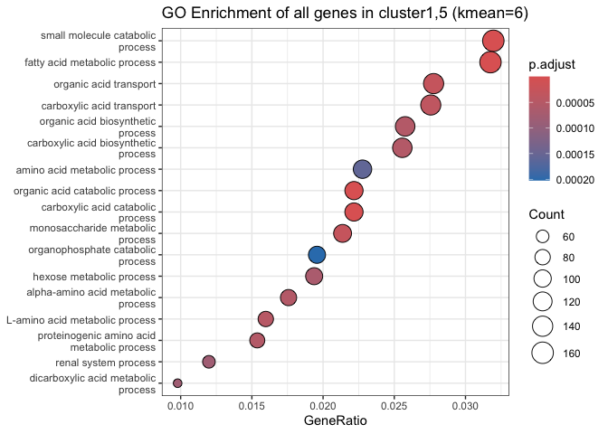

```r
######################## Only regulated genes
genes_k6_c1 = names(which(cluster_list[["k6"]]$cluster == 1))
genes_k6_c5 = names(which(cluster_list[["k6"]]$cluster == 5))

genes_k6_c1_c5 = union(genes_k6_c1, genes_k6_c5)

# GO enrich all regulated gene in cluster 4
ego_genes_k6_c15 = enrichGO(gene = genes_k6_c1_c5,
                OrgDb = org.Hs.eg.db,
                keyType = "ENSEMBL",
                ont = "ALL",
                pAdjustMethod = "BH",
                pvalueCutoff = 0.05,
                readable = TRUE)

# Dotplot of GO result
dotplot(ego_genes_k6_c15, showCategory = 17) +
  theme_bw() +
  ggtitle("GO Enrichment of all genes in cluster1,5 (kmean=6)")
```

```r
# https://biit.cs.ut.ee/gplink/l/aczkZsEbgT7
gpro_genes_k6_c1 = gost(query = genes_k6_c1_c5, # input geneIDs
                organism = "hsapiens", # organism of interest
                significant = TRUE, # return only the significant result
                exclude_iea = FALSE,  # do not exclude GO electronic annotation
                evcodes = TRUE, # include evidence code
                user_threshold = 0.05, # P-value threshold (eg. P value<= 0.05)
                correction_method = "g_SCS",  # Multiple testing correction method
                domain_scope = "annotated",
                as_short_link = TRUE) # domain scope
```

#### 3.4.1.2 k6, c2, c6

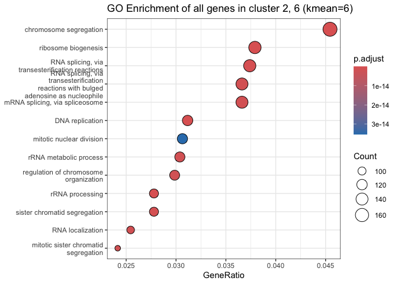

```r
######################## Only regulated genes
genes_k6_c2 = names(which(cluster_list[["k6"]]$cluster == 2))
genes_k6_c6 = names(which(cluster_list[["k6"]]$cluster == 6))

genes_k6_c2_c6 <- union(genes_k6_c2, genes_k6_c6)

# GO enrich all regulated gene in cluster 5
ego_genes_k6_c2_c6 = enrichGO(gene = genes_k6_c2_c6,
                OrgDb = org.Hs.eg.db,
                keyType = "ENSEMBL",
                ont = "BP",
                pAdjustMethod = "BH",
                pvalueCutoff = 0.05,
                readable = TRUE)

# Dotplot of GO result
dotplot(ego_genes_k6_c2_c6, showCategory = 13, font.size = 5) +
  theme_bw() +
  ggtitle("GO Enrichment of all genes in cluster 2, 6 (kmean=6)")
```

```r
# https://biit.cs.ut.ee/gplink/l/aLCY7NV-BRF
gpro_ego_genes_k6_c2_c6 = gost(query = ego_genes_k6_c2_c6, # input geneIDs
                organism = "hsapiens", # organism of interest
                significant = TRUE, # return only the significant result
                exclude_iea = FALSE,  # do not exclude GO electronic annotation
                evcodes = TRUE, # include evidence code
                user_threshold = 0.05, # P-value threshold (eg. P value<= 0.05)
                correction_method = "g_SCS",  # Multiple testing correction method
                domain_scope = "annotated",
                as_short_link = TRUE) # domain scope
```

#### 3.4.1.3 Upregulated genes

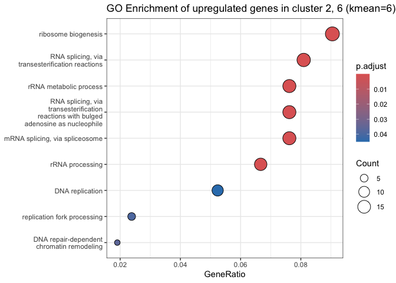

```r
# Extract genes downregulated in 3 datasets
genes_k6_c2_c6_df = purrr::map(res_list, function(df) filter(df, GeneID %in% genes_k6_c2_c6))

up_all_k6_c2_c6 = purrr::map(genes_k6_c2_c6_df, function(df) filter(df, up_down == "up"))

# GO enrich all upregulated gene in cluster 5
ego_genes_up_k6_c2_c6 = enrichGO(gene = up_all_k6_c2_c6$U2AF1$GeneID,
                OrgDb = org.Hs.eg.db,
                keyType = "ENSEMBL",
                ont = "BP",
                pAdjustMethod = "BH",
                pvalueCutoff = 0.05,
                readable = TRUE)

# Dotplot of GO result
dotplot(ego_genes_up_k6_c2_c6, showCategory = 13, font.size = 5) +
  theme_bw() +
  ggtitle("GO Enrichment of upregulated genes in cluster 2, 6 (kmean=6)")
```

### 3.4.2 How many of downregulated genes in c26 are splicing factors?

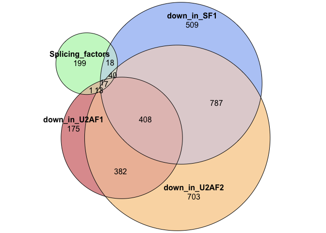

```r
down_all_k6_c2_c6 = purrr::map(genes_k6_c2_c6_df, function(df) filter(df, up_down == "down"))

down_all_k6_c2_c6_genes = unique(c(
  down_all_k6_c2_c6$U2AF1$SYMBOL,
  down_all_k6_c2_c6$U2AF2$SYMBOL,
  down_all_k6_c2_c6$SF1$SYMBOL
))

ggven_down_cluster2_SF = list(
  down_in_U2AF1 = down_all_k6_c2_c6$U2AF1$GeneID,
  down_in_U2AF2 = down_all_k6_c2_c6$U2AF2$GeneID,
  down_in_SF1 = down_all_k6_c2_c6$SF1$GeneID,
  Splicing_factors = as_anno$splice_ENSEMBL)

plot(eulerr::euler(ggven_down_cluster2_SF),
       fills = list(fill = c("#BD241EFF", "#F5B355", "cornflowerblue", "lightgreen"), alpha = 0.5),
       quantities = TRUE,
       stroke_size = 1, # control border size
       set_name_size = 1, # set name size
       text_size = 2)
```

### 3.4.3 Are the splicing factor genes that share down-expression patterns across 3 knockdowns (U2AF1, U2AF2, SF1) correlated or co-regulated?

I use 7 overlapping genes upon 3 cluster 2 and 6 downregulated-gene sets (as seeds) to find their target or source genes, respectively, and their correlation values. My idea is: overlap → correlation → network → screen for splicing factor modules → co-regulation?

```r
# Get genes overlapping among 3 datasets
down_all_c26_SF_genes = Reduce(intersect, list(down_all_k6_c2_c6$U2AF1$GeneID,
                                         down_all_k6_c2_c6$U2AF2$GeneID,
                                         down_all_k6_c2_c6$SF1$GeneID))

# filter only SF
down_all_intersect_SF_genes = as_anno[as_anno$splice_ENSEMBL %in% down_all_c26_SF_genes,]

# obtain source or target genes and correlation values in only overlapping downregulated genes in cluster 2 and 6
cor_down_all_intersect_SF = correlation_anno %>%
  filter(so %in% down_all_intersect_SF_genes$splice_SYMBOL |
           tg %in% down_all_intersect_SF_genes$splice_SYMBOL)
# view
cor_down_all_intersect_SF
```

```
# A tibble: 6 × 6
  edges           so      tg        cor source_class      target_class
  <chr>           <chr>   <chr>   <dbl> <chr>             <chr>
1 DDX46-SF3A2     SF3A2   DDX46   0.356 U2 snRNP          U2 snRNP related
2 DDX46-SF3A1     SF3A1   DDX46   0.316 U2 snRNP          U2 snRNP related
3 DDX46-SF3A3     SF3A3   DDX46   0.301 U2 snRNP          U2 snRNP related
4 DDX46-SF3B4     SF3B4   DDX46   0.295 U2 snRNP          U2 snRNP related
5 DDX46-SNRPA1    SNRPA1  DDX46   0.292 U2 snRNP          U2 snRNP related
6 HNRNPDL-TCERG1L TCERG1L HNRNPDL 0.290 chromatin-related hnRNP
```

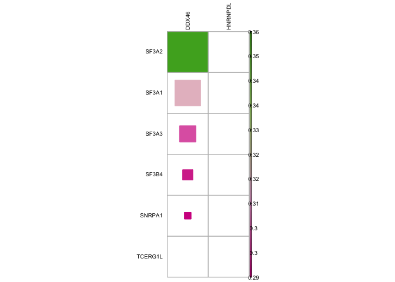

```r
cor_down_all_intersect_SF_mat = cor_down_all_intersect_SF %>%
  dplyr::select(so, tg, cor) %>%
  pivot_wider(names_from = tg, values_from = cor) %>%
  column_to_rownames("so") %>%
  as.matrix()

corrplot(cor_down_all_intersect_SF_mat,
         method = "square",
         is.corr = FALSE,
         col = colorRampPalette(RColorBrewer::brewer.pal(4, "PiYG"))(200),
         cl.cex = 0.6,
         tl.cex = 0.6,
         tl.col = "black",
         na.label = " ")
```

To expand the plot, I let correlated genes (so) being target genes (tg) to detect other source genes that might relate to them. So that I could find complex regulatory network of SFs that might co-regulate each other?

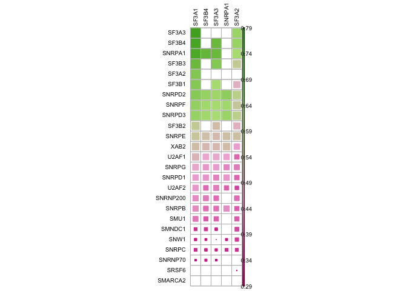

```r
cor2_down_all_intersect_SF = correlation_anno %>%
  filter(tg %in% unique(cor_down_all_intersect_SF$so))

cor2_down_all_intersect_SF_mat = cor2_down_all_intersect_SF %>%
  dplyr::select(so, tg, cor) %>%
  pivot_wider(names_from = tg, values_from = cor) %>%
  column_to_rownames("so") %>%
  as.matrix()

corrplot(cor2_down_all_intersect_SF_mat,
         method = "square",
         is.corr = FALSE,
         col = colorRampPalette(RColorBrewer::brewer.pal(4, "PiYG"))(200),
         cl.cex = 0.6,
         tl.cex = 0.6,
         tl.col = "black",
         na.label = " ")
```

### 3.4.4 Uniquely downregulated genes in U2AF1, SF1

**U2AF1**

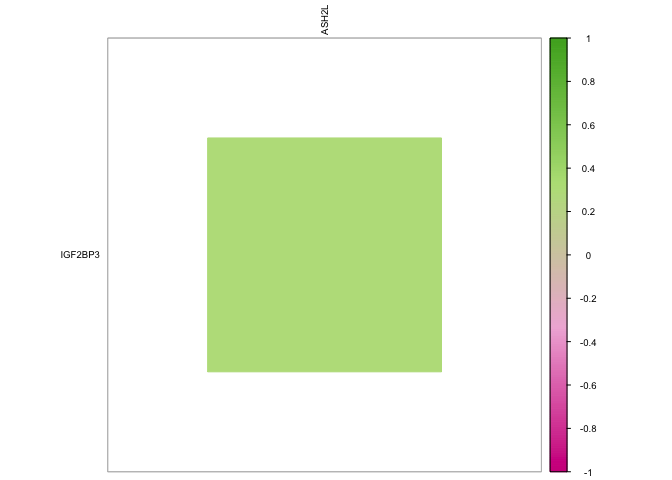

```r
################################## U2AF1
uniq_U2AF1_down_c26_genes = down_all_k6_c2_c6$U2AF1$GeneID[down_all_k6_c2_c6$U2AF1$GeneID %in%
                                        setdiff(down_all_k6_c2_c6$U2AF1$GeneID,
                                                union(down_all_k6_c2_c6$U2AF2$GeneID, down_all_k6_c2_c6$SF1$GeneID))]

uniq_U2AF1_down_c26_SF = intersect(uniq_U2AF1_down_c26_genes, as_anno_genes)

uniq_U2AF1_down_c26_SF = as_anno[as_anno$splice_ENSEMBL %in% uniq_U2AF1_down_c26_SF,]

cor_uniq_U2AF1_down_c26_SF = correlation_anno %>%
  filter(so %in% uniq_U2AF1_down_c26_SF$splice_SYMBOL)

cor_uniq_U2AF1_down_c26_SF_mat = cor_uniq_U2AF1_down_c26_SF %>%
  dplyr::select(so, tg, cor) %>%
  pivot_wider(names_from = tg, values_from = cor) %>%
  column_to_rownames("so") %>%
  as.matrix()

corrplot(cor_uniq_U2AF1_down_c26_SF_mat,
         method = "square",
         col = colorRampPalette(RColorBrewer::brewer.pal(4, "PiYG"))(200),
         cl.cex = 0.6,
         tl.cex = 0.6,
         tl.col = "black",
         na.label = " ")
```

**SF1**

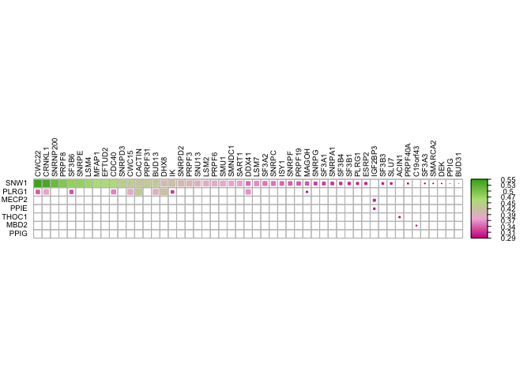

```r
################################## SF1
uniq_SF1_down_c26_genes = down_all_k6_c2_c6$SF1$GeneID[down_all_k6_c2_c6$SF1$GeneID %in%
                                        setdiff(down_all_k6_c2_c6$SF1$GeneID,
                                                union(down_all_k6_c2_c6$U2AF2$GeneID, down_all_k6_c2_c6$U2AF1$GeneID))]

uniq_SF1_down_c26_SF = intersect(uniq_SF1_down_c26_genes, as_anno_genes)

uniq_SF1_down_c26_SF = as_anno[as_anno$splice_ENSEMBL %in% uniq_SF1_down_c26_genes,]

cor_uniq_SF1_down_c26_SF = correlation_anno %>%
  filter(so %in% uniq_SF1_down_c26_SF$splice_SYMBOL|
         tg %in% uniq_U2AF1_down_c26_SF$splice_SYMBOL)

cor_uniq_SF1_down_c26_SF_mat = cor_uniq_SF1_down_c26_SF %>%
  dplyr::select(so, tg, cor) %>%
  pivot_wider(names_from = tg, values_from = cor) %>%
  column_to_rownames("so") %>%
  as.matrix()

corrplot(cor_uniq_SF1_down_c26_SF_mat,
         method = "square",
         is.corr = FALSE,
         col = colorRampPalette(RColorBrewer::brewer.pal(4, "PiYG"))(200),
         cl.cex = 0.6,
         tl.cex = 0.6,
         tl.col = "black",
         na.label = " ")
```

### 3.4.5 Co-splicing downregulated between 2 datasets

**SF1 & U2AF2**

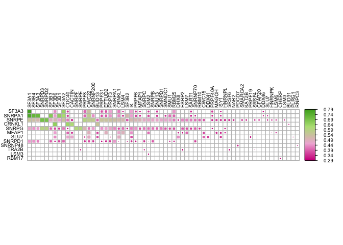

```r
################################## SF1 and U2AF2
# Get intersecting genes between U2AF2, SF1, and splicing factors
U2AF2_SF1_splicing_genes <- Reduce(intersect, list(
  down_all_k6_c2_c6$SF1$GeneID,
  down_all_k6_c2_c6$U2AF2$GeneID,
  as_anno_genes
))

# Exclude genes also downregulated in U2AF1
U2AF2_SF1_noU2AF1_genes <- setdiff(
  U2AF2_SF1_splicing_genes,
  down_all_k6_c2_c6$U2AF1$GeneID
)

U2AF2_SF1_noU2AF1_genes_df = as_anno[as_anno$splice_ENSEMBL %in% U2AF2_SF1_noU2AF1_genes,]

cor_U2AF2_SF1_noU2AF1_genes_df = correlation_anno %>%
  filter(so %in% U2AF2_SF1_noU2AF1_genes_df$splice_SYMBOL)

#cor2_U2AF2_SF1_noU2AF1_genes_df = correlation_anno %>%
#  filter(tg %in% unique(cor_U2AF2_SF1_noU2AF1_genes_df$so) |
#        tg %in% unique(cor_U2AF2_SF1_noU2AF1_genes_df$tg) |
#        so %in% unique(cor_U2AF2_SF1_noU2AF1_genes_df$tg) |
#        so %in% unique(cor_U2AF2_SF1_noU2AF1_genes_df$tg))

#cor_U2AF2_SF1_noU2AF1_genes_df = bind_rows(cor_U2AF2_SF1_noU2AF1_genes_df, cor2_U2AF2_SF1_noU2AF1_genes_df) %>%
#  distinct(edges, .keep_all = TRUE)

cor_U2AF2_SF1_noU2AF1_genes_df_mat = cor_U2AF2_SF1_noU2AF1_genes_df %>%
  dplyr::select(so, tg, cor) %>%
  pivot_wider(names_from = tg, values_from = cor) %>%
  column_to_rownames("so") %>%
  as.matrix()

corrplot(cor_U2AF2_SF1_noU2AF1_genes_df_mat,
         method = "square",
         is.corr = FALSE,
         cl.lim = c(0,1),
         col = colorRampPalette(RColorBrewer::brewer.pal(4, "PiYG"))(200),
         cl.cex = 0.6,
         tl.cex = 0.6,
         tl.col = "black",
         na.label = " ")
```

**U2AF1 & U2AF2**

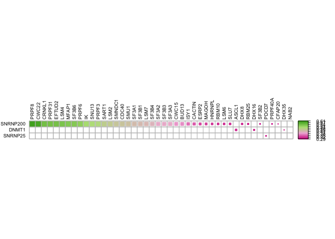

```r
################################## U2AF1 and U2AF2
# Get intersecting genes between U2AF2, SF1, and splicing factors
U2AF2_U2AF1_splicing_genes <- Reduce(intersect, list(
  down_all_k6_c2_c6$U2AF1$GeneID,
  down_all_k6_c2_c6$U2AF2$GeneID,
  as_anno_genes
))

# Exclude genes also downregulated in U2AF1
U2AF2_U2AF1_noSF1_genes <- setdiff(
  U2AF2_U2AF1_splicing_genes,
  down_all_k6_c2_c6$SF1$GeneID
)

U2AF2_U2AF1_noSF1_genes_df = as_anno[as_anno$splice_ENSEMBL %in% U2AF2_U2AF1_noSF1_genes,]

cor_U2AF2_U2AF1_noSF1_genes_df = correlation_anno %>%
  filter(so %in% U2AF2_U2AF1_noSF1_genes_df$splice_SYMBOL)

#cor2_U2AF2_U2AF1_noSF1_genes_df = correlation_anno %>%
#  filter(tg %in% unique(cor_U2AF2_U2AF1_noSF1_genes_df$so) |
#        tg %in% unique(cor_U2AF2_U2AF1_noSF1_genes_df$tg) |
#        so %in% unique(cor_U2AF2_U2AF1_noSF1_genes_df$tg) |
#        so %in% unique(cor_U2AF2_U2AF1_noSF1_genes_df$tg))

#cor_U2AF2_U2AF1_noSF1_genes_df = bind_rows(cor_U2AF2_U2AF1_noSF1_genes_df, cor2_U2AF2_U2AF1_noSF1_genes_df) %>%
#  distinct(edges, .keep_all = TRUE)

cor_U2AF2_U2AF1_noSF1_genes_df_mat = cor_U2AF2_U2AF1_noSF1_genes_df %>%
  dplyr::select(so, tg, cor) %>%
  pivot_wider(names_from = tg, values_from = cor) %>%
  column_to_rownames("so") %>%
  as.matrix()

corrplot(cor_U2AF2_U2AF1_noSF1_genes_df_mat,
         method = "square",
         is.corr = FALSE,
         col = colorRampPalette(RColorBrewer::brewer.pal(4, "PiYG"))(200),
         cl.cex = 0.6,
         tl.cex = 0.6,
         tl.col = "black",
         na.label = " ")
```

### 3.4.6 k6, c3, c4

function for scatter plot

```r
genes_k6_c3 = names(which(cluster_list[["k6"]]$cluster == 3))

genes_k6_c4 = names(which(cluster_list[["k6"]]$cluster == 4))

# Get genes in the interested clusters
genes_k6_c3_c4 = union(genes_k6_c3, genes_k6_c4)

# Create a function
log2FC_compare2 = function(d1, d2, var1, var2) {

  # Merge 2 datasets in to 1 df
  d1_d2_df = inner_join(d1, d2, by = "GeneID", suffix = c(var1, var2))

  #add SYMBOL/ gene name column
  d1_d2_df$splice_SYMBOL = as_anno$splice_SYMBOL[match(d1_d2_df$GeneID, as_anno$splice_ENSEMBL)]

  # Add regulated column if a gene regulated either in only 1 dataset or both
  d1_d2_df = d1_d2_df %>% mutate(
    regulate_direction = case_when(
        .[[paste0("regulated", var1)]] == "TRUE"   & .[[paste0("regulated", var2)]] == "TRUE"   ~ "both regulated",
        .[[paste0("regulated", var1)]] == "TRUE"   & .[[paste0("regulated", var2)]] == "FALSE" ~ paste("only regulated in", var1),
        .[[paste0("regulated", var1)]] == "FALSE" & .[[paste0("regulated", var2)]] == "TRUE"   ~ paste("only regulated in", var2),
        .[[paste0("regulated", var1)]] == "FALSE" & .[[paste0("regulated", var2)]] == "FALSE" ~ "none regulation",
        TRUE ~ NA_character_), # If genes are nonregulated, assign it as NA
    GOI = case_when(
      grepl("U2AF2", splice_SYMBOL) ~ splice_SYMBOL,
      grepl("U2AF1", splice_SYMBOL) ~ splice_SYMBOL,
      grepl("SF1", splice_SYMBOL) ~ splice_SYMBOL,
      TRUE ~ NA)) # Assign all GOI related to splicing using grepl()

  # Arrange regulate = FALSE first so they will be plotted first => points will be backwards and remove NA
  d1_d2_df$regulate_direction = factor(
  d1_d2_df$regulate_direction,
  levels = c("none regulation", "only regulated in U2AF2", "only regulated in U2AF1", "both regulated")
)

# Then arrange so that "none regulation" comes first
d1_d2_df = d1_d2_df %>% arrange(regulate_direction)


return(d1_d2_df)
}
```

**U2AF2 and U2AF1 in c3**

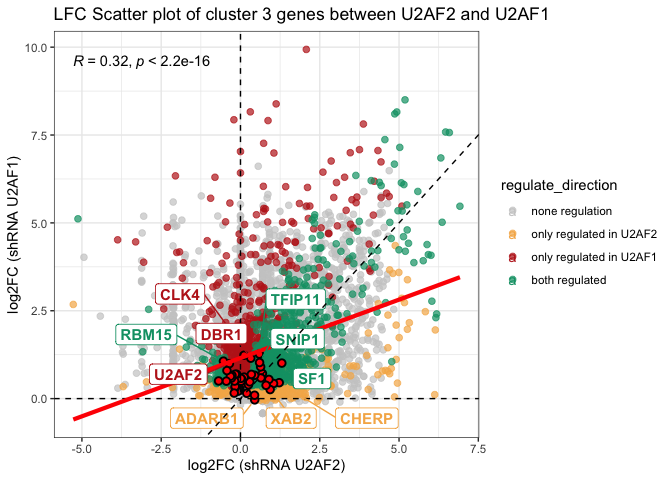

```r
res_U2AF2_c3.df = res_U2AF2.df[res_U2AF2.df$GeneID %in% genes_k6_c3, ]

res_U2AF1_c3.df = res_U2AF1.df[res_U2AF1.df$GeneID %in% genes_k6_c3, ]

# apply function on each pair of comparison
U2AF2_U2AF1_c3_df = log2FC_compare2(res_U2AF2_c3.df, res_U2AF1_c3.df, "U2AF2", "U2AF1")

ggplot(
  U2AF2_U2AF1_c3_df,
  aes(x = log2FoldChangeU2AF2,
      y = log2FoldChangeU2AF1,
      label = splice_SYMBOL,
      color = regulate_direction)) +
  # All genes
  geom_point(aes(color = regulate_direction), size = 2, alpha = 0.7) +
  # GOI genes in black and larger
  geom_point(data = subset(U2AF2_U2AF1_c3_df, !is.na(splice_SYMBOL)),
             color = "black", stroke = 1, size = 2, shape = 21, fill = "red") +
  scale_color_manual(
    values = c("both regulated" = "#009E73",
               "none regulation" = "grey80",
               "only regulated in U2AF1" = "#BD241EFF",
               "only regulated in U2AF2" = "#F5B355"),
    na.value = "grey80") +
  geom_hline(yintercept = 0, linetype = "dashed") +
  geom_vline(xintercept = 0, linetype = "dashed") +
  geom_smooth(method = "lm", se = FALSE, color = "red", linewidth = 1.5, alpha = 0.8) +
  geom_label_repel(
    data = subset(U2AF2_U2AF1_c3_df, !is.na(splice_SYMBOL)),
    aes(label = splice_SYMBOL, color = regulate_direction),
    box.padding = 0.5,
    point.padding = 0.5,
    size = 4,
    label.size = 0.3,
    max.overlaps = 70,   # how all labels regardless of overlap
    force = 1.5,           # repel force; increase if still overlapping
    force_pull = 0.5,      # pull labels toward points
    show.legend = FALSE,
    fontface = "bold") +
  geom_abline(linetype = "dashed") +
  stat_cor(aes(group =1), method = "pearson") +
  labs(
    x = "log2FC (shRNA U2AF2)",
    y = "log2FC (shRNA U2AF1)",
    title = "LFC Scatter plot of cluster 3 genes between U2AF2 and U2AF1") +
  theme_bw()
```

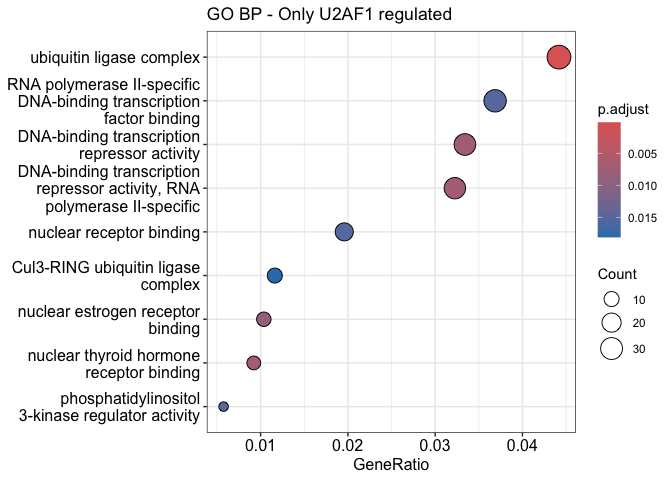

```r
# Only regulated in U2AF2
genes_U2AF2_c3_only <- U2AF2_U2AF1_c3_df %>%
  filter(regulate_direction == "only regulated in U2AF2") %>%
  pull(GeneID)

# Only regulated in U2AF1
genes_U2AF1_c3_only <- U2AF2_U2AF1_c3_df %>%
  filter(regulate_direction == "only regulated in U2AF1") %>%
  pull(GeneID)

# Regulated in both
genes_c3_both <- U2AF2_U2AF1_c3_df %>%
  filter(regulate_direction == "both regulated") %>%
  pull(GeneID)

# GO enrichment for U2AF2-only
ego_U2AF2_c3 <- enrichGO(
  gene          = genes_U2AF2_c3_only,
  OrgDb         = org.Hs.eg.db,
  keyType       = "ENSEMBL",   # or "SYMBOL" depending on your IDs
  ont           = "ALL",        # Biological Process
  pAdjustMethod = "BH",
  qvalueCutoff  = 0.05,
  readable      = TRUE
)

# U2AF1-only
ego_U2AF1_c3 <- enrichGO(
  gene          = genes_U2AF1_c3_only,
  OrgDb         = org.Hs.eg.db,
  keyType       = "ENSEMBL",
  ont           = "ALL",
  pAdjustMethod = "BH",
  qvalueCutoff  = 0.05,
  readable      = TRUE
)

# Both regulated
ego_c3_both <- enrichGO(
  gene          = genes_c3_both,
  OrgDb         = org.Hs.eg.db,
  keyType       = "ENSEMBL",
  ont           = "ALL",
  pAdjustMethod = "BH",
  qvalueCutoff  = 0.05,
  readable      = TRUE
)

dotplot(ego_U2AF1_c3, showCategory = 15, title = "GO BP - Only U2AF1 regulated")
```

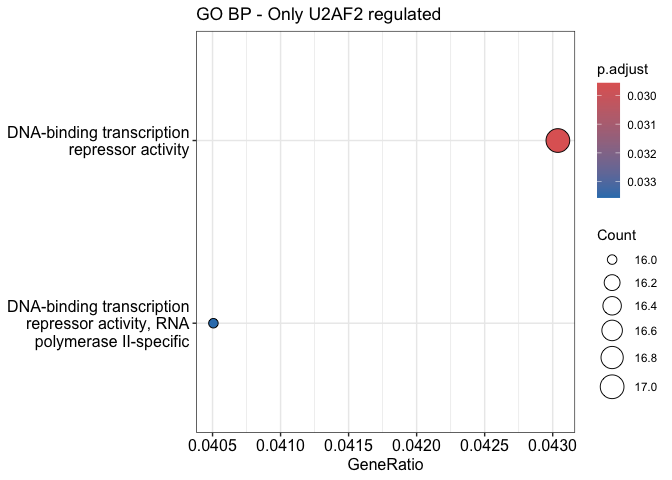

```r
dotplot(ego_U2AF2_c3, showCategory = 15, title = "GO BP - Only U2AF2 regulated")
```

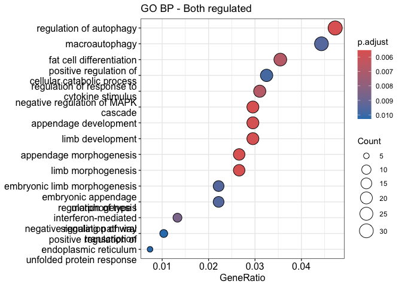

```r
dotplot(ego_c3_both, showCategory = 15, title = "GO BP - Both regulated")
```

**U2AF2 and U2AF1 in c4**

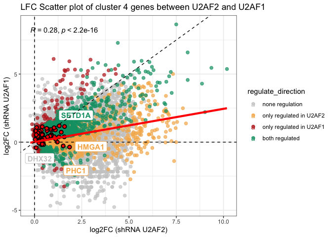

```r
res_U2AF2_c4.df = res_U2AF2.df[res_U2AF2.df$GeneID %in% genes_k6_c4, ]

res_U2AF1_c4.df = res_U2AF1.df[res_U2AF1.df$GeneID %in% genes_k6_c4, ]

# apply function on each pair of comparison
U2AF2_U2AF1_c4_df = log2FC_compare2(res_U2AF2_c4.df, res_U2AF1_c4.df, "U2AF2", "U2AF1")

ggplot(
  U2AF2_U2AF1_c4_df,
  aes(x = log2FoldChangeU2AF2,
      y = log2FoldChangeU2AF1,
      label = splice_SYMBOL,
      color = regulate_direction)) +
  # All genes
  geom_point(aes(color = regulate_direction), size = 2, alpha = 0.7) +
  # GOI genes in black and larger
  geom_point(data = subset(U2AF2_U2AF1_c4_df, !is.na(splice_SYMBOL)),
             color = "black", stroke = 1, size = 2, shape = 21, fill = "red") +
  scale_color_manual(
    values = c("both regulated" = "#009E73",
               "none regulation" = "grey80",
               "only regulated in U2AF1" = "#BD241EFF",
               "only regulated in U2AF2" = "#F5B355"),
    na.value = "grey80") +
  geom_hline(yintercept = 0, linetype = "dashed") +
  geom_vline(xintercept = 0, linetype = "dashed") +
  geom_smooth(method = "lm", se = FALSE, color = "red", linewidth = 1.5, alpha = 0.8) +
  geom_label_repel(
    data = subset(U2AF2_U2AF1_c4_df, !is.na(splice_SYMBOL)),
    aes(label = splice_SYMBOL, color = regulate_direction),
    box.padding = 0.5,
    point.padding = 0.5,
    size = 4,
    label.size = 0.3,
    max.overlaps = 70,   # how all labels regardless of overlap
    force = 1.5,           # repel force; increase if still overlapping
    force_pull = 0.5,      # pull labels toward points
    show.legend = FALSE,
    fontface = "bold") +
  geom_abline(linetype = "dashed") +
  stat_cor(aes(group =1), method = "pearson") +
  labs(
    x = "log2FC (shRNA U2AF2)",
    y = "log2FC (shRNA U2AF1)",
    title = "LFC Scatter plot of cluster 4 genes between U2AF2 and U2AF1") +
  theme_bw()
```

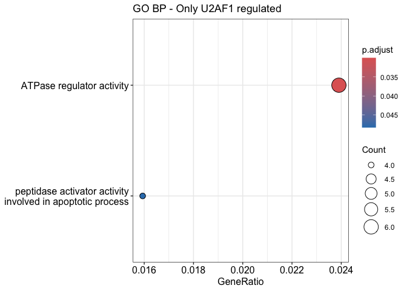

```r
# Only regulated in U2AF2
genes_U2AF2_c4_only <- U2AF2_U2AF1_c4_df %>%
  filter(regulate_direction == "only regulated in U2AF2") %>%
  pull(GeneID)

# Only regulated in U2AF1
genes_U2AF1_c4_only <- U2AF2_U2AF1_c4_df %>%
  filter(regulate_direction == "only regulated in U2AF1") %>%
  pull(GeneID)

# Regulated in both
genes_c4_both <- U2AF2_U2AF1_c4_df %>%
  filter(regulate_direction == "both regulated") %>%
  pull(GeneID)

# GO enrichment for U2AF2-only
ego_U2AF2_c4 <- enrichGO(
  gene          = genes_U2AF2_c4_only,
  OrgDb         = org.Hs.eg.db,
  keyType       = "ENSEMBL",   # or "SYMBOL" depending on your IDs
  ont           = "ALL",        # Biological Process
  pAdjustMethod = "BH",
  qvalueCutoff  = 0.05,
  readable      = TRUE
)

# U2AF1-only
ego_U2AF1_c4 <- enrichGO(
  gene          = genes_U2AF1_c4_only,
  OrgDb         = org.Hs.eg.db,
  keyType       = "ENSEMBL",
  ont           = "ALL",
  pAdjustMethod = "BH",
  qvalueCutoff  = 0.05,
  readable      = TRUE
)

# Both regulated
ego_c4_both <- enrichGO(
  gene          = genes_c4_both,
  OrgDb         = org.Hs.eg.db,
  keyType       = "ENSEMBL",
  ont           = "ALL",
  pAdjustMethod = "BH",
  qvalueCutoff  = 0.05,
  readable      = TRUE
)

dotplot(ego_U2AF1_c4, showCategory = 15, title = "GO BP - Only U2AF1 regulated")
```

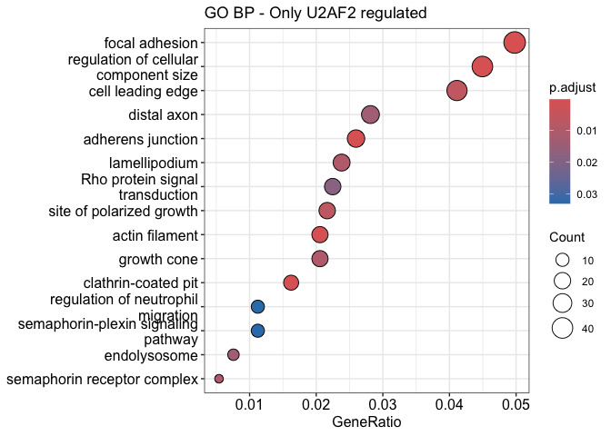

```r
dotplot(ego_U2AF2_c4, showCategory = 15, title = "GO BP - Only U2AF2 regulated")
```

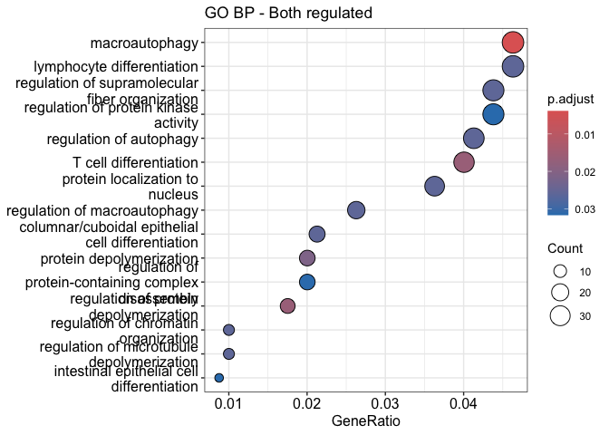

```r
dotplot(ego_c4_both, showCategory = 15, title = "GO BP - Both regulated")
```